# punto2

- **Algoritmos Genéticos (GA):** Los algoritmos genéticos son una técnica de optimización inspirada en la evolución natural. Utilizan operaciones como la selección, la mutación y el cruce para generar nuevas soluciones a partir de una población inicial. En el contexto del TSP, una solución sería una secuencia específica de ciudades. El algoritmo genético intentaría encontrar la secuencia que minimiza el costo total de viaje.
- **Optimización de Colonias de Hormigas (ACO):** La optimización de colonias de hormigas es otra técnica de optimización inspirada en el comportamiento de las hormigas en la naturaleza. Las hormigas depositan feromonas en su camino, y las hormigas tienden a seguir los caminos con más feromonas. En el contexto del TSP, las “hormigas” explorarían diferentes secuencias de ciudades, y las secuencias con menor costo de viaje recibirían más “feromonas”. Con el tiempo, la solución convergería hacia la secuencia óptima.

Estos algoritmos se utilizan en este contexto para encontrar la secuencia óptima de ciudades que el vendedor debe visitar para minimizar el costo total de viaje, teniendo en cuenta varios factores como los peajes, el costo del combustible y el salario del vendedor. La representación con un gif animado o un video del comportamiento de la mejor solución en un mapa de Colombia permitiría visualizar el recorrido óptimo encontrado por estos algoritmos, para este ejercicio tomamos como referencia que el vendedor se moviliza en un auto renault sandero stepway.

- **Lista de ciudades:** Se define una lista de ciudades que el vendedor debe visitar.
- **Inicialización de la matriz:** Se inicializa una matriz vacía con ceros. Esta matriz se llenará con los costos de viaje entre cada par de ciudades.
- **Diccionario de datos:** Se define un diccionario para almacenar los datos para cada par de ciudades. Los datos incluyen la suma de los peajes, la eficiencia del combustible, la distancia en kilómetros, el precio de la gasolina, el salario del vendedor y el tiempo de viaje en horas.
- **Rellenar la matriz con los costos de viaje:** Para cada par de ciudades, se calcula el costo de viaje como la suma de los peajes, el producto de la eficiencia del combustible, la distancia y el precio de la gasolina, y el producto del salario del vendedor y el tiempo de viaje. El costo se asigna a la celda correspondiente en la matriz.
- **Conversión de la matriz a un DataFrame:** La matriz se convierte en un DataFrame de pandas para facilitar su manipulación. El DataFrame se transpone y su índice se establece en la lista de ciudades.

|  | Palmira | Pasto | Tuluá | Bogota | Pereira | Armenia | Manizales | Valledupar | Montería | Soledad | Cartagena | Barranquilla | Medellín | Bucaramanga | Cúcuta |
| --- | --- | --- | --- | --- | --- | --- | --- | --- | --- | --- | --- | --- | --- | --- | --- |
| Palmira | 0.000 | 341447.840 | 83529.488 | 418535.88 | 186100.760 | 164305.400 | 247544.640 | 941326.08 | 766227.68 | 1015229.920 | 957289.44 | 1052642.880 | 383975.44 | 660642.08 | 824613.60 |
| Pasto | 338681.840 | 0.000 | 394947.480 | 728006.00 | 497480.000 | 476621.200 | 558330.480 | 1234108.64 | 1077430.32 | 1304672.960 | 1270659.36 | 1377119.040 | 708197.84 | 972744.72 | 1124179.84 |
| Tuluá | 70236.336 | 396424.880 | 0.000 | 409956.64 | 106093.480 | 104347.168 | 179278.000 | 279822.04 | 671801.04 | 925263.440 | 899813.12 | 1116812.800 | 315092.16 | 793212.16 | 759150.40 |
| Bogota | 425065.760 | 740937.680 | 345066.000 | 0.00 | 329440.800 | 262040.240 | 260009.200 | 714528.08 | 720801.28 | 826225.120 | 862752.00 | 844404.480 | 392627.60 | 375279.76 | 454275.52 |
| Pereira | 187555.320 | 501182.560 | 106038.160 | 295529.20 | 0.000 | 48846.344 | 75875.152 | 756265.20 | 580120.16 | 819092.240 | 792025.28 | 908037.360 | 212231.60 | 480171.12 | 643526.00 |
| Armenia | 153015.440 | 478217.360 | 83022.208 | 252491.20 | 48070.088 | 0.000 | 122547.776 | 771474.08 | 628454.16 | 900627.440 | 808906.24 | 909044.080 | 259727.68 | 494826.80 | 658265.04 |
| Manizales | 245611.360 | 560552.516 | 177151.480 | 259906.68 | 75554.144 | 122626.696 | 0.000 | 696801.20 | 555988.32 | 794628.480 | 760388.80 | 834133.680 | 177335.56 | 419813.88 | 583785.40 |
| Valledupar | 953565.360 | 1280524.160 | 871265.600 | 726738.72 | 756138.320 | 780295.840 | 694912.200 | 0.00 | 358852.56 | 259842.120 | 314902.40 | 271997.680 | 636392.12 | 371410.32 | 424566.96 |
| Montería | 756764.280 | 1067736.160 | 661018.080 | 748205.36 | 605262.480 | 652039.400 | 568698.720 | 360915.64 | 0.00 | 284569.720 | 253526.92 | 303049.520 | 374914.36 | 491889.48 | 542026.36 |
| Soledad | 1088239.760 | 1394734.720 | 1006999.200 | 843170.96 | 904755.280 | 906429.440 | 822365.360 | 258332.24 | 308006.64 | 0.000 | 117170.16 | 12755.568 | 623474.04 | 497718.00 | 549752.00 |
| Cartagena | 963841.360 | 1274757.920 | 881652.240 | 559214.88 | 812173.600 | 867920.960 | 774724.720 | 319598.00 | 256933.92 | 117723.360 | 0.00 | 110450.560 | 739543.12 | 525784.40 | 568808.88 |
| Barranquilla | 1062495.320 | 1357117.920 | 1007822.840 | 855547.80 | 896992.080 | 917525.800 | 824930.200 | 271215.08 | 295075.44 | 12989.536 | 110956.56 | 0.000 | 633742.24 | 727350.16 | 564460.40 |
| Medellín | 360585.120 | 794320.320 | 292808.240 | 369126.88 | 211293.040 | 270004.000 | 188283.840 | 632653.20 | 372408.72 | 611444.240 | 587060.64 | 639376.640 | 0.00 | 356005.92 | 518744.16 |
| Bucaramanga | 675209.360 | 837933.920 | 582398.800 | 346287.68 | 480597.440 | 504375.840 | 420090.480 | 373924.08 | 491375.36 | 500057.680 | 522148.00 | 512600.480 | 357792.40 | 0.00 | 168097.68 |
| Cúcuta | 822480.480 | 1138328.640 | 740797.360 | 452425.60 | 736912.640 | 666497.440 | 579595.440 | 427064.48 | 544017.88 | 552644.880 | 577564.64 | 567463.920 | 519360.80 | 183674.64 | 0.00 |

utilizamos los siguientes parámetros: fitness_func = tsp_fitness

num_parents_mating = 4

sol_per_pop = 8 num_genes = len(costMatrix)

parent_selection_type = "sss" keep_parents = 1

crossover_type = "single_point"

mutation_type = "swap" mutation_percent_genes = 10

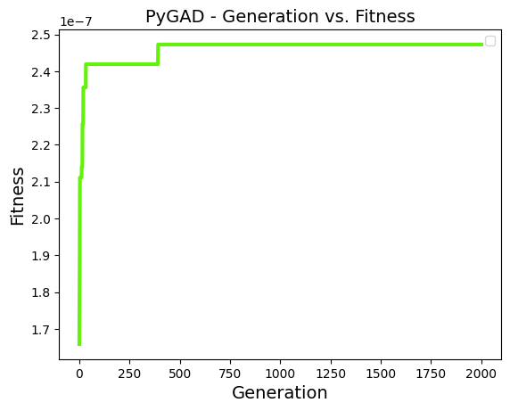

```
La mejor solución obtenida al terminar el algoritmo fue el vector: [ 6  4  5  3 13 14 12  0  1  2  7 11  9 10  8] con un fitness de 2.472663209781955e-07
```

```
WARNING:matplotlib.legend:No artists with labels found to put in legend.  Note that artists whose label start with an underscore are ignored when legend() is called with no argument.
```

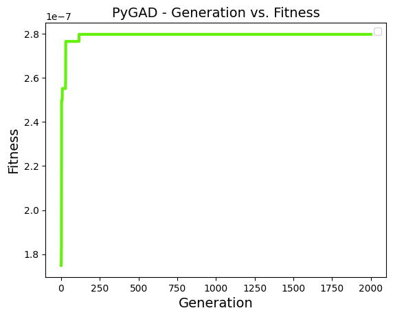

```
La mejor solución obtenida al terminar el algoritmo fue el vector: [ 0  1  2  6  3 13 14  7  9 11 10  8 12  4  5] con un fitness de 2.7975320279874325e-07
```

```
WARNING:matplotlib.legend:No artists with labels found to put in legend.  Note that artists whose label start with an underscore are ignored when legend() is called with no argument.
```

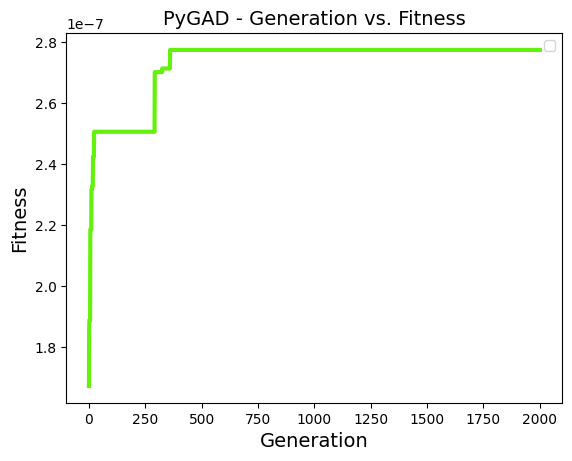

```
La mejor solución obtenida al terminar el algoritmo fue el vector: [ 2  7 11  9 10  8 14 13  3 12  6  4  5  0  1] con un fitness de 2.773444498787193e-07
```

```
WARNING:matplotlib.legend:No artists with labels found to put in legend.  Note that artists whose label start with an underscore are ignored when legend() is called with no argument.
```

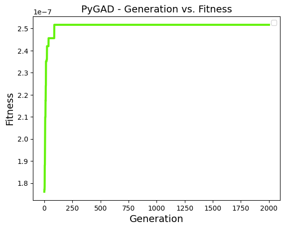

```
La mejor solución obtenida al terminar el algoritmo fue el vector: [ 2  7 13  3 14  9 11 10  8 12  6  4  5  1  0] con un fitness de 2.51691754686646e-07
```

```
WARNING:matplotlib.legend:No artists with labels found to put in legend.  Note that artists whose label start with an underscore are ignored when legend() is called with no argument.
```

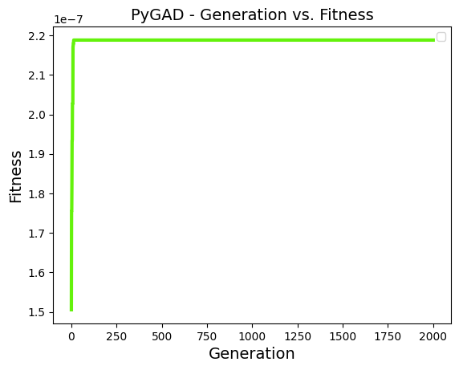

```
La mejor solución obtenida al terminar el algoritmo fue el vector: [ 3 13 14  5  2  7  9 10 11  8  1  0  4  6 12] con un fitness de 2.1881293388197852e-07
```

```
WARNING:matplotlib.legend:No artists with labels found to put in legend.  Note that artists whose label start with an underscore are ignored when legend() is called with no argument.
```

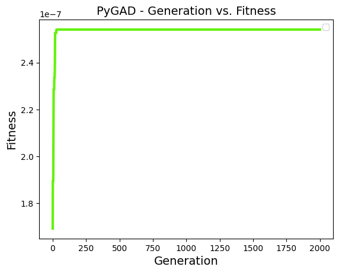

```
La mejor solución obtenida al terminar el algoritmo fue el vector: [ 7  8 10  9 11 12  6  2  1  0  4  5  3 13 14] con un fitness de 2.5412812640822556e-07
```

```
WARNING:matplotlib.legend:No artists with labels found to put in legend.  Note that artists whose label start with an underscore are ignored when legend() is called with no argument.
```

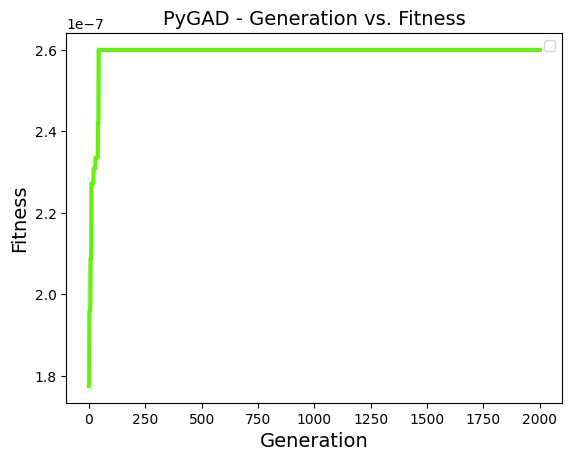

```
La mejor solución obtenida al terminar el algoritmo fue el vector: [ 8 10 11  9  7 14 13  2  0  1  4  5  3  6 12] con un fitness de 2.599972277639591e-07
```

```
WARNING:matplotlib.legend:No artists with labels found to put in legend.  Note that artists whose label start with an underscore are ignored when legend() is called with no argument.
```

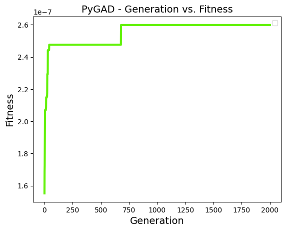

```
La mejor solución obtenida al terminar el algoritmo fue el vector: [ 7 10  9 11  8 12 13 14  3  6  1  0  4  5  2] con un fitness de 2.598121139183544e-07
```

```
WARNING:matplotlib.legend:No artists with labels found to put in legend.  Note that artists whose label start with an underscore are ignored when legend() is called with no argument.
```

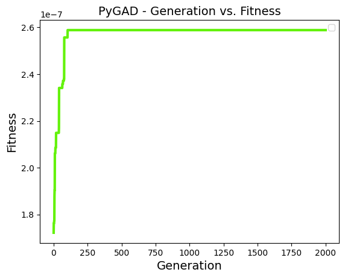

```
La mejor solución obtenida al terminar el algoritmo fue el vector: [14 13  3  5  4 12  6  0  1  2  7  8 11  9 10] con un fitness de 2.588469041764271e-07
```

```
WARNING:matplotlib.legend:No artists with labels found to put in legend.  Note that artists whose label start with an underscore are ignored when legend() is called with no argument.
```

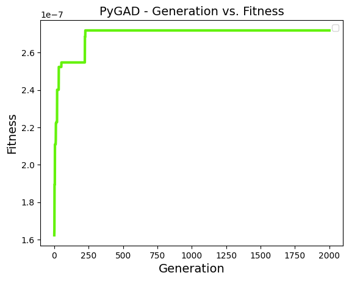

```
La mejor solución obtenida al terminar el algoritmo fue el vector: [ 1  0  4 12  8 10  9 11  7 14 13  3  5  6  2] con un fitness de 2.719358772242842e-07
```

```
La mejor solución obtenida al terminar el algoritmo fue el vector: [ 4  3 13 14  7  9 10 11  8 12  6  2  1  0  5] con un fitness de 2.6764150352423587e-07
```

```
array([ 6,  4,  5,  3, 13, 14, 12,  0,  1,  2,  7, 11,  9, 10,  8])
```

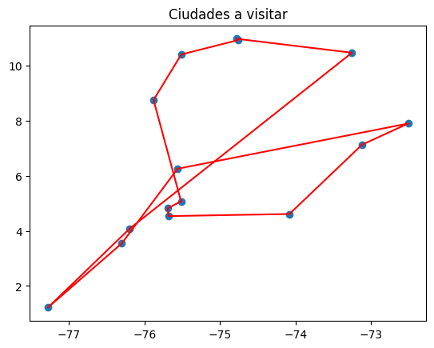

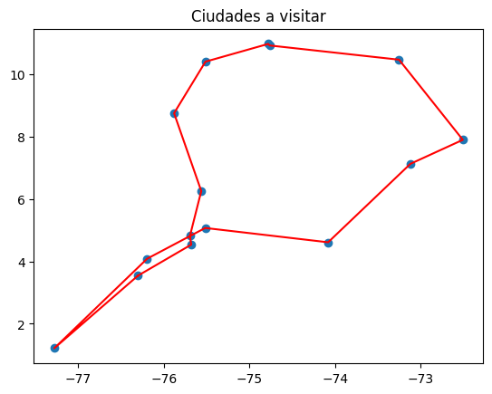

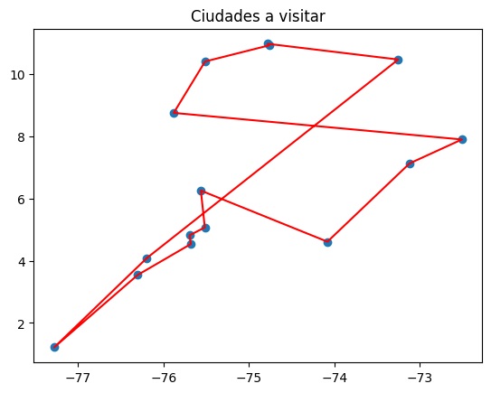

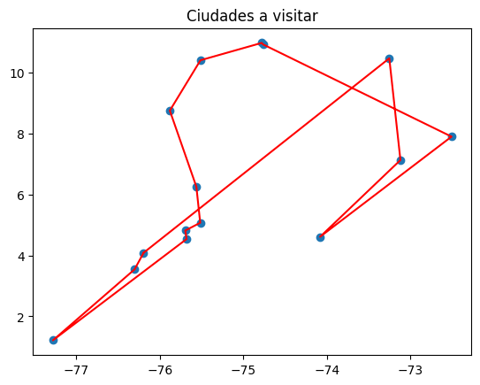

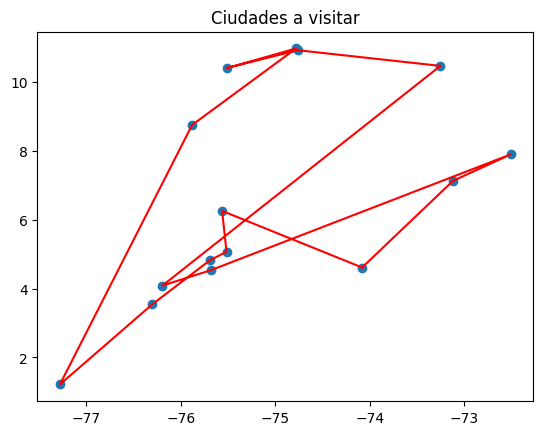

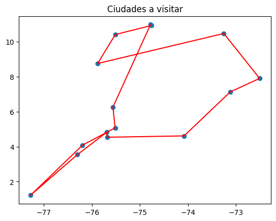

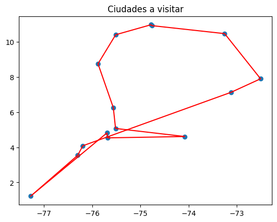

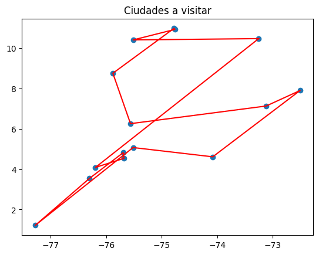

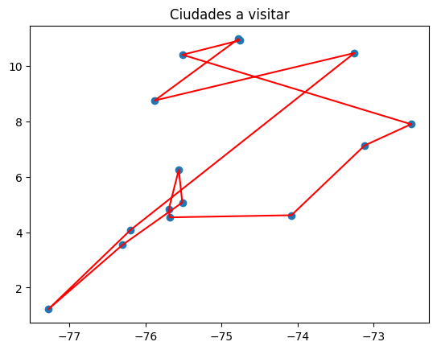

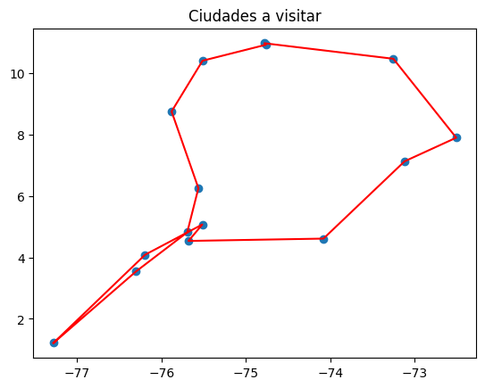

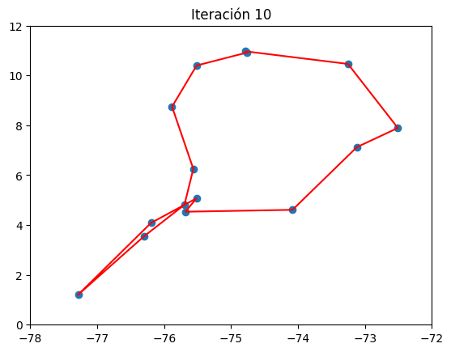

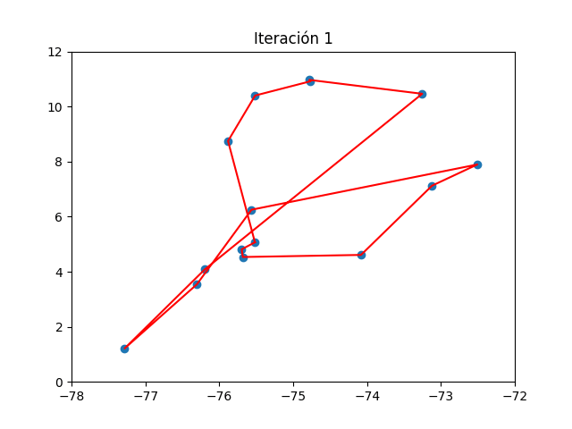

[interactive chart not shown]

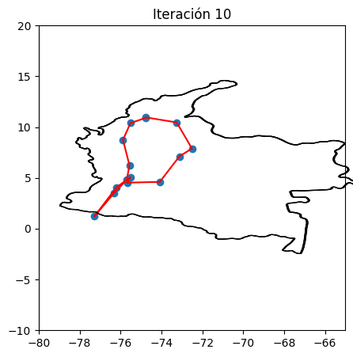

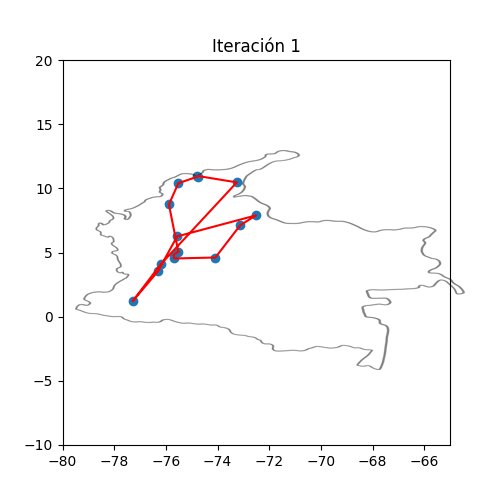

. **Problema de Ant Colony Optimization Código tomado de Ant Colony Optimization. Todos los créditos son de Jerzy Pawlikowski**

```
Beginning ACO Optimization with 40 iterations...
Best score at iteration 0: 39.41; overall: 39.41 (0s)
Best score at iteration 1: 38.03; overall: 38.03 (0s)
Best score at iteration 2: 36.28; overall: 36.28 (0s)
Best score at iteration 3: 35.58; overall: 35.58 (0s)
Best score at iteration 4: 35.2; overall: 35.2 (0s)
Best score at iteration 5: 36.7; overall: 35.2 (0s)
Best score at iteration 6: 30.72; overall: 30.72 (0s)
Best score at iteration 7: 27.14; overall: 27.14 (0s)
Best score at iteration 8: 32.82; overall: 27.14 (0s)
Best score at iteration 9: 27.08; overall: 27.08 (0s)
Best score at iteration 10: 26.82; overall: 26.82 (0s)
Best score at iteration 11: 28.25; overall: 26.82 (0s)
Best score at iteration 12: 27.95; overall: 26.82 (0s)
Best score at iteration 13: 26.39; overall: 26.39 (0s)
Best score at iteration 14: 26.39; overall: 26.39 (0s)
Best score at iteration 15: 26.39; overall: 26.39 (0s)
Best score at iteration 16: 26.39; overall: 26.39 (0s)
Best score at iteration 17: 24.95; overall: 24.95 (0s)
Best score at iteration 18: 24.95; overall: 24.95 (0s)
Best score at iteration 19: 24.77; overall: 24.77 (0s)
Best score at iteration 20: 24.95; overall: 24.77 (0s)
Best score at iteration 21: 24.95; overall: 24.77 (0s)
Best score at iteration 22: 24.94; overall: 24.77 (0s)
Best score at iteration 23: 24.95; overall: 24.77 (0s)
Best score at iteration 24: 24.94; overall: 24.77 (0s)
Best score at iteration 25: 24.94; overall: 24.77 (0s)
Best score at iteration 26: 24.95; overall: 24.77 (0s)
Best score at iteration 27: 23.32; overall: 23.32 (0s)
Best score at iteration 28: 24.94; overall: 23.32 (0s)
Best score at iteration 29: 24.94; overall: 23.32 (0s)
Best score at iteration 30: 24.94; overall: 23.32 (0s)
Best score at iteration 31: 24.94; overall: 23.32 (0s)
Best score at iteration 32: 23.34; overall: 23.32 (0s)
Best score at iteration 33: 23.34; overall: 23.32 (0s)
Best score at iteration 34: 23.34; overall: 23.32 (0s)
Best score at iteration 35: 23.34; overall: 23.32 (0s)
Best score at iteration 36: 23.34; overall: 23.32 (0s)
Best score at iteration 37: 23.32; overall: 23.32 (0s)
Best score at iteration 38: 23.32; overall: 23.32 (0s)
Best score at iteration 39: 23.32; overall: 23.32 (0s)
ACO fitted.  Runtime: 0 minutes.  Best score: 23.32133764064965
```

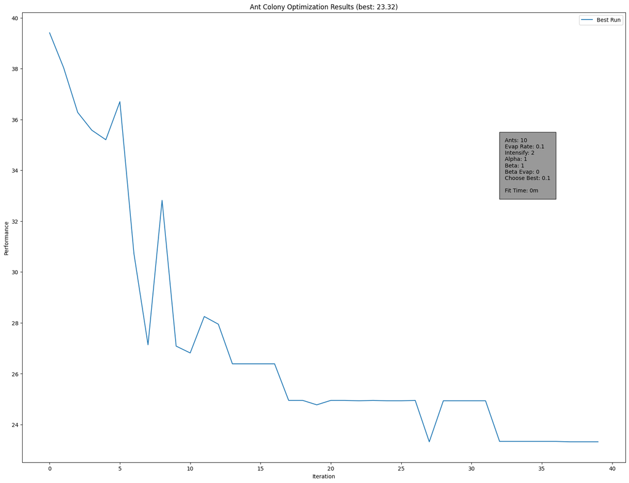

```
[7, 9, 11, 10, 8, 12, 6, 4, 5, 2, 0, 1, 3, 13, 14, 7]
```

Estamos en la búsqueda de validar y exhibir la ruta óptima, teniendo en cuenta únicamente las coordenadas

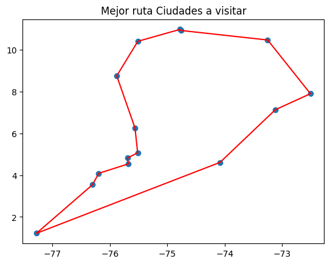

Una vez que comprendemos de manera más profunda el comportamiento de los datos, procedemos a introducir lo que hemos establecido como el costo del viaje

```
Beginning ACO Optimization with 11 iterations...
Best score at iteration 0: 4253850.79; overall: 4253850.79 (0s)
Best score at iteration 1: 4373277.12; overall: 4253850.79 (0s)
Best score at iteration 2: 3562673.48; overall: 3562673.48 (0s)
Best score at iteration 3: 3592242.3; overall: 3562673.48 (0s)
Best score at iteration 4: 3562673.48; overall: 3562673.48 (0s)
Best score at iteration 5: 3562673.48; overall: 3562673.48 (0s)
Best score at iteration 6: 3521241.16; overall: 3521241.16 (0s)
Best score at iteration 7: 3562673.48; overall: 3521241.16 (0s)
Best score at iteration 8: 3521241.16; overall: 3521241.16 (0s)
Best score at iteration 9: 3521241.16; overall: 3521241.16 (0s)
Best score at iteration 10: 3521241.16; overall: 3521241.16 (0s)
ACO fitted.  Runtime: 0 minutes.  Best score: 3521241.1599999997
Beginning ACO Optimization with 12 iterations...
Best score at iteration 0: 3911085.4; overall: 3911085.4 (0s)
Best score at iteration 1: 3947505.14; overall: 3911085.4 (0s)
Best score at iteration 2: 4123123.74; overall: 3911085.4 (0s)
Best score at iteration 3: 3534293.75; overall: 3534293.75 (0s)
Best score at iteration 4: 3811916.27; overall: 3534293.75 (0s)
Best score at iteration 5: 3496889.43; overall: 3496889.43 (0s)
Best score at iteration 6: 3496889.43; overall: 3496889.43 (0s)
Best score at iteration 7: 3469674.59; overall: 3469674.59 (0s)
Best score at iteration 8: 3469674.59; overall: 3469674.59 (0s)
Best score at iteration 9: 3469674.59; overall: 3469674.59 (0s)
Best score at iteration 10: 3469674.59; overall: 3469674.59 (0s)
Best score at iteration 11: 3469674.59; overall: 3469674.59 (0s)
ACO fitted.  Runtime: 0 minutes.  Best score: 3469674.5919999997
Beginning ACO Optimization with 13 iterations...
Best score at iteration 0: 4421711.94; overall: 4421711.94 (0s)
Best score at iteration 1: 4318807.69; overall: 4318807.69 (0s)
Best score at iteration 2: 4404188.24; overall: 4318807.69 (0s)
Best score at iteration 3: 3667059.13; overall: 3667059.13 (0s)
Best score at iteration 4: 3667059.13; overall: 3667059.13 (0s)
Best score at iteration 5: 3569472.84; overall: 3569472.84 (0s)
Best score at iteration 6: 3569472.84; overall: 3569472.84 (0s)
Best score at iteration 7: 3545657.63; overall: 3545657.63 (0s)
Best score at iteration 8: 3516811.1; overall: 3516811.1 (0s)
Best score at iteration 9: 3489596.26; overall: 3489596.26 (0s)
Best score at iteration 10: 3489596.26; overall: 3489596.26 (0s)
Best score at iteration 11: 3489596.26; overall: 3489596.26 (0s)
```

[output cut: 120 more lines]

```
Best score at iteration 6: 4032210.84; overall: 3785734.59 (0s)
Best score at iteration 7: 3870736.93; overall: 3785734.59 (0s)
Best score at iteration 8: 3785807.17; overall: 3785734.59 (0s)
Best score at iteration 9: 3640503.09; overall: 3640503.09 (0s)
Best score at iteration 10: 3696635.34; overall: 3640503.09 (0s)
Best score at iteration 11: 3696635.34; overall: 3640503.09 (0s)
Best score at iteration 12: 3590553.41; overall: 3590553.41 (0s)
Best score at iteration 13: 3590553.41; overall: 3590553.41 (0s)
Best score at iteration 14: 3564323.16; overall: 3564323.16 (0s)
Best score at iteration 15: 3550809.98; overall: 3550809.98 (0s)
Best score at iteration 16: 3550809.98; overall: 3550809.98 (0s)
Best score at iteration 17: 3550809.98; overall: 3550809.98 (0s)
Best score at iteration 18: 3550809.98; overall: 3550809.98 (0s)
Best score at iteration 19: 3550809.98; overall: 3550809.98 (0s)
ACO fitted.  Runtime: 0 minutes.  Best score: 3550809.9839999997
```

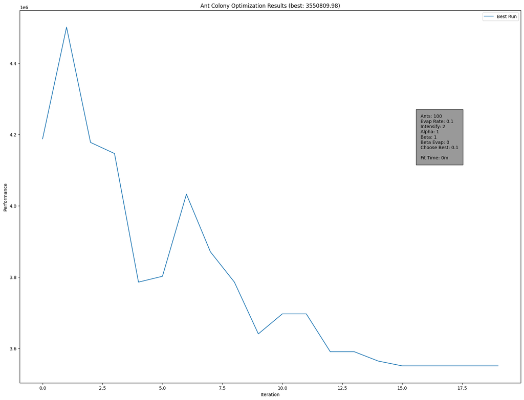

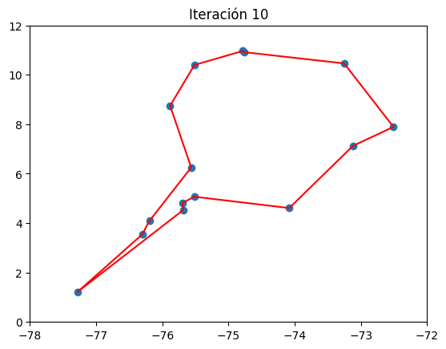

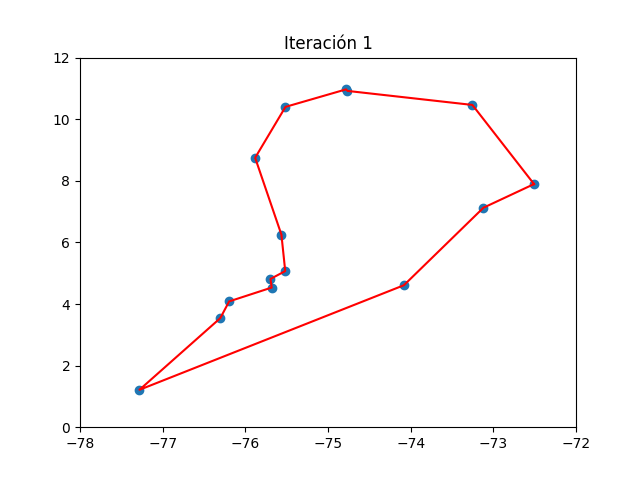

[interactive chart not shown]

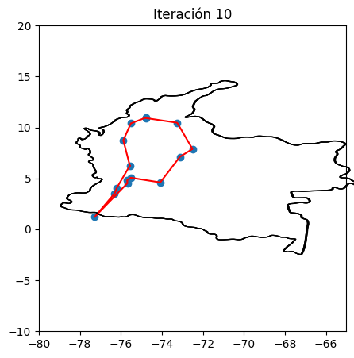

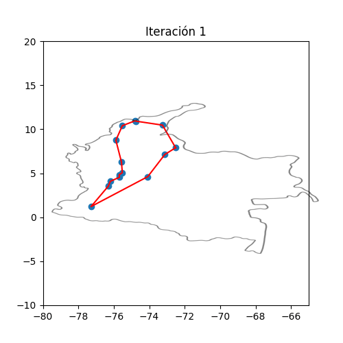